# Education and Perceived Discrimination Among Jews: A Paradox?

Dag van de Sociologie 2026

Christian Czymara (NIDI), Frank van Tubgergen (NIDI, UU)

26 May 2026

## Introduction

# Theory

## The Integration Paradox

- Two mechanisms of integration paradox (IP) (Schaeffer and Kas 2024)
  - *Opportunities* to face discrimination: More contact with majority and exposure to majority institutions
  - *Cognitive susceptibility* to frame experiences as discrimination: Increased understanding of discrimination and raised expectations

## The “opportunity-risk” mechanism: Opportunity

- Migrants: More contact with majority -> higher discrimination perceptions
- Contact with majority likely relatively stable across education for Jews due to small size and low segregation
- Education should not influence contact opportunity

## The “opportunity-risk” mechanism: Risk

- Key factor: *risk of discrimination per contact*
- Blatant antisemitism is largely taboo among highly educated majority (Meuleman et al. 2018; Nyhan, Yamaya, and Zeitzoff 2024) and minority (Czymara et al. 2025; Öztürk and Pickel 2021) members
- General tendancy to interact with others who are similar (Bankier-Karp and Beider 2025; McPherson, Smith-Lovin, and Cook 2001)
- More educated Jews more likely to ineract with more educated individuals where open antisemtism is stigmatized
  - *H1: Higher education leads to* lower perceived religious discrimination*

## Identifiability

- Integration paradox primarily concerns those who are identifiable as minorities (racial phenotype, religious clothing, or distinct names)
- Similarly, negative education effect should mostly exist for Jews who are recognized as Jewish (more likely to be targeted based on religion)
  - *H2a: H1 is stronger among Jews who publicly wear Jewish symbols or clothing*
  - *H2b: H1 is stronger among religious Jews*
  - *H2c: H1 is stronger among Jews with a strong Jewish identity*

# Data

## Method

- Linear probability models with country fixed effects (same results with logistic regression or hierarchical linear models)
- Regressing perceived discrimination on higher educational attainment
- Controls:
  - Demographic characteristics (confounders): gender, age, marital status
  - Economic characteristics (colliders?): income (satisfaction), employment status

# Results

## Education and Preceived Discrimination

|  | M1: Bivariate | M2: M1 + Demographic controls | M3: M2 + Economic controls |
| --- | --- | --- | --- |
| Predictors | Estimates | Estimates | Estimates |
| high edu [Tertiary] | -0.04 *** (0.01) | -0.04 *** (0.01) | -0.02 * (0.01) |
| Observations | 13115 | 13115 | 13115 |
| * p<0.05 ** p<0.01 *** p<0.001 |  |  |  |

## Religiosity and Religious Identity

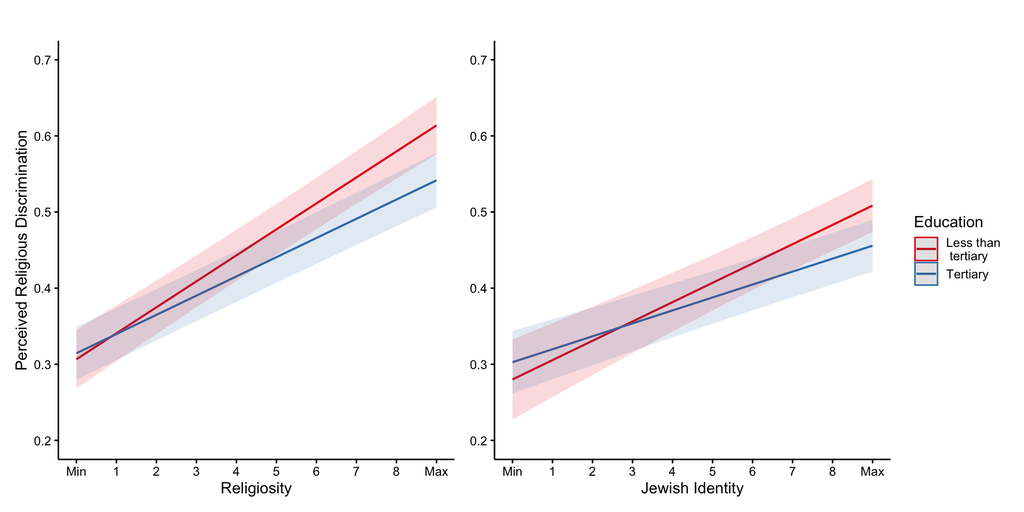

## Visibility

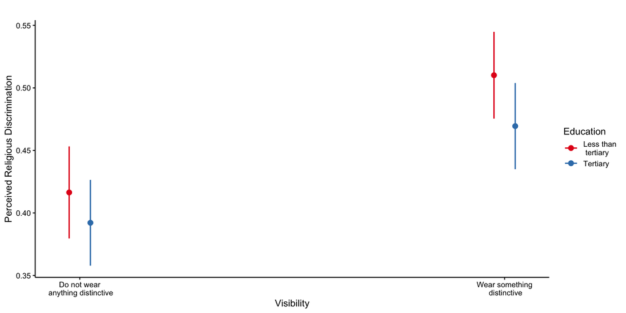

# The US

## Jewish Americans in 2020 study

- Probability survey of Jewish adults in the US, online and mail (Pew Research Center 2019–2020)
- Outcome (dummy if at least one is “yes”):
  - *Have you been called offensive names because you are Jewish/of your Jewish background?*
  - *Have you been made to feel unwelcome because you are Jewish/of your Jewish background?*
  - *Have you been physically threatened or attacked because you are Jewish/of your Jewish background?*

## Education and Preceived Discrimination

|  | M1: Bivariate | M2: M1 + Demographic controls | M3: M2 + Economic controls |
| --- | --- | --- | --- |
| Predictors | Estimates | Estimates | Estimates |
| high_edu: Tertiary | -0.06 *** (0.02) | -0.05 *** (0.02) | -0.04 * (0.02) |
| Observations | 4872 | 4872 | 4872 |
| * p<0.05 ** p<0.01 *** p<0.001 |  |  |  |

## Religiosity

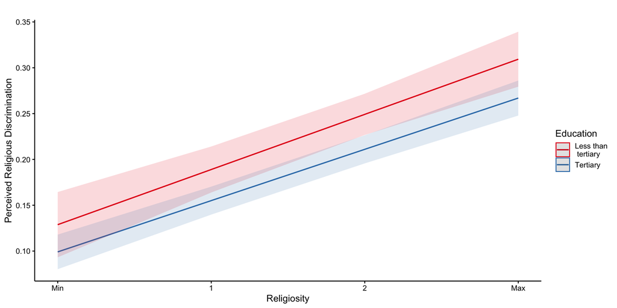

## Visibility

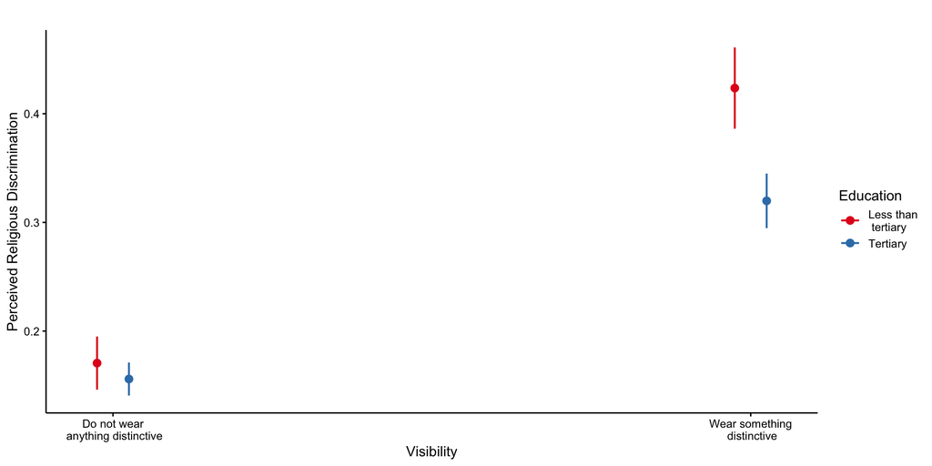

# Summing up

## Summary & Conclusion

- Migrants: More education -> more majority contact -> more discrimination
- Jews: Contact depends less on education, so less open prejudice among higher-educated majority members is key
- IP is driven by interplay between contact quantity and the risk of discrimination per contact
- Which component dominates depends on the position of the minority group

# Annex

## Number of Respondents by Country

```
    Belgium     Denmark       Spain      France       Italy     Hungary
        650         510         483        3349         611         535
Netherlands     Austria      Poland      Sweden          UK
       1059         452         354        1021        4091
```

## Distribution across Countries

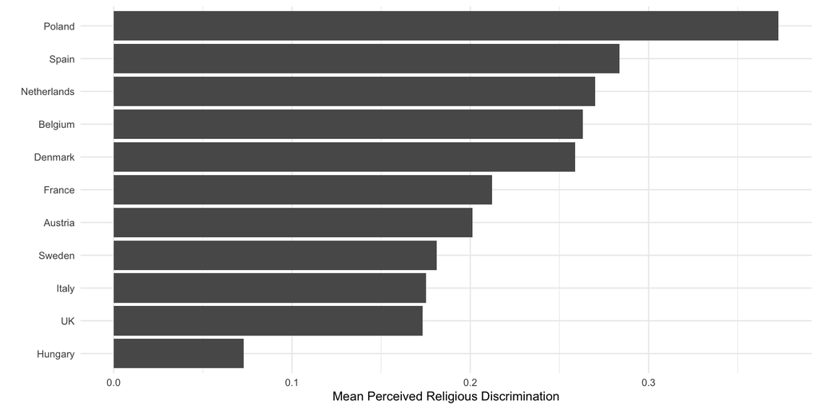